# Function Features and Intervals

Mr. Worley

Tues Oct 14

# Agenda

- Entrance ticket!
- Slides
- OCW_1014_A
- OCW_1014_B
- PCW_1014

# Function Features

- **Domain**
- **Range**
- **Increasing/decreasing**
- **Positive/negative**
- Extrema (local and global minimums and maximums)
  - We will cover these another day
- Intercepts (with $x$ axis or $y$ axis)
  - These you already know, and we will cover these another day.

# Interval notation

- Standard interval notation looks kind of like the notation we use for [Cartesian coordinates](https://en.wikipedia.org/wiki/Cartesian_coordinate_system).
- Parentheses indicate an exclusive boundary.
- Brackets indicate an inclusive boundary.
- A union symbol ($\cup$) indicates a union of multiple intervals.
- Examples:
  - $(3,5)$ means all real numbers between 3 and 5, but NOT including the boundaries. As an inequality, $3<x<5$.
  - $(3,5]$ means all real numbers between 3 and 5, but NOT including 3. As an inequality, $3<x\le 5$.
  - $[3,5)$ means all real numbers between 3 and 5, but NOT including 5. As an inequality, $3\le x < 5$.
  - $[3,5]$ means all real numbers between 3 and 5, including both boundaries. As an inequality, $3\le x \le 5$.

Using interval notation, express the real numbers highlighted on the number line below.

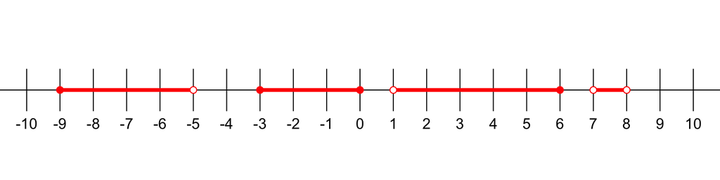

- $$[-9,-5) ~\cup~ [-3,0] ~\cup~ (1,6] ~\cup~
  (7,8)$$

# Domain of a function

- The [domain](https://en.wikipedia.org/wiki/Domain_of_a_function) of a function describes the set of possible inputs (the possible $x$ values).
- Using interval notation, express the domain of the function shown below.
- Imagine the function flattening onto the $x$ axis.

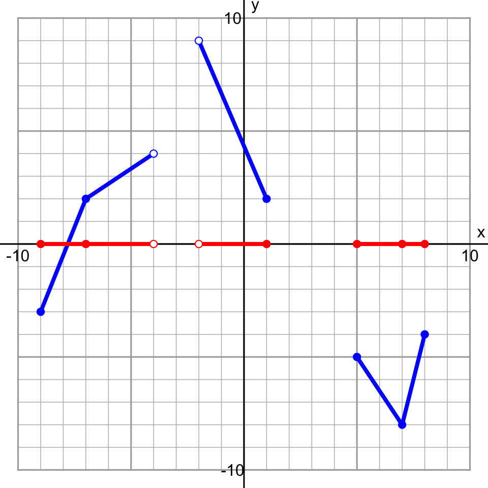

# Range of a function

- The [range](https://en.wikipedia.org/wiki/Range_of_a_function) of a function describes the set of possible outputs (the possible $y$ values).
- Using interval notation, express the range of the function shown below.
- Imagine the function flattening onto the $y$ axis.

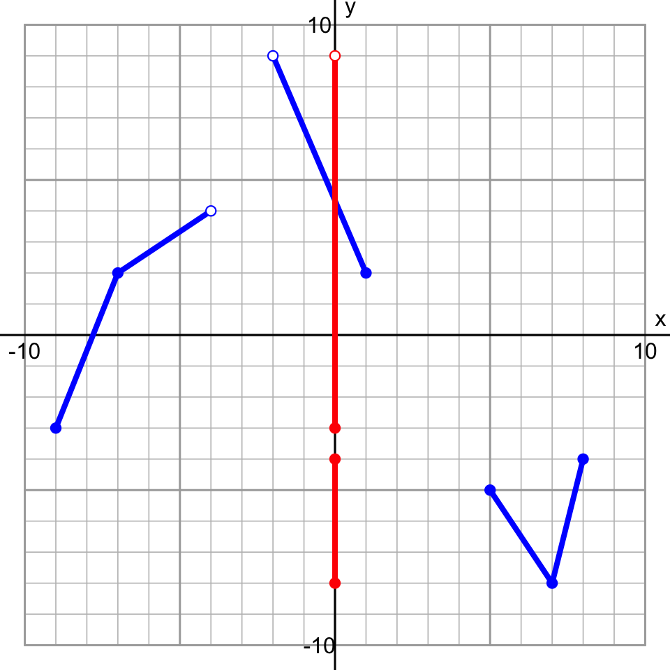

- Range:
  $$[-8,-4]~\cup~[-3,9)$$

# Where is function INCREASING?

- Follow curve left to right (like when reading English).
- I imagine an ant hiking left to right along the mountain ridges.
- If curve is going up, it is increasing.
- Using function notation, express where the function is increasing.
- Notice, on functions, we indicate “where” with the $x$ values.

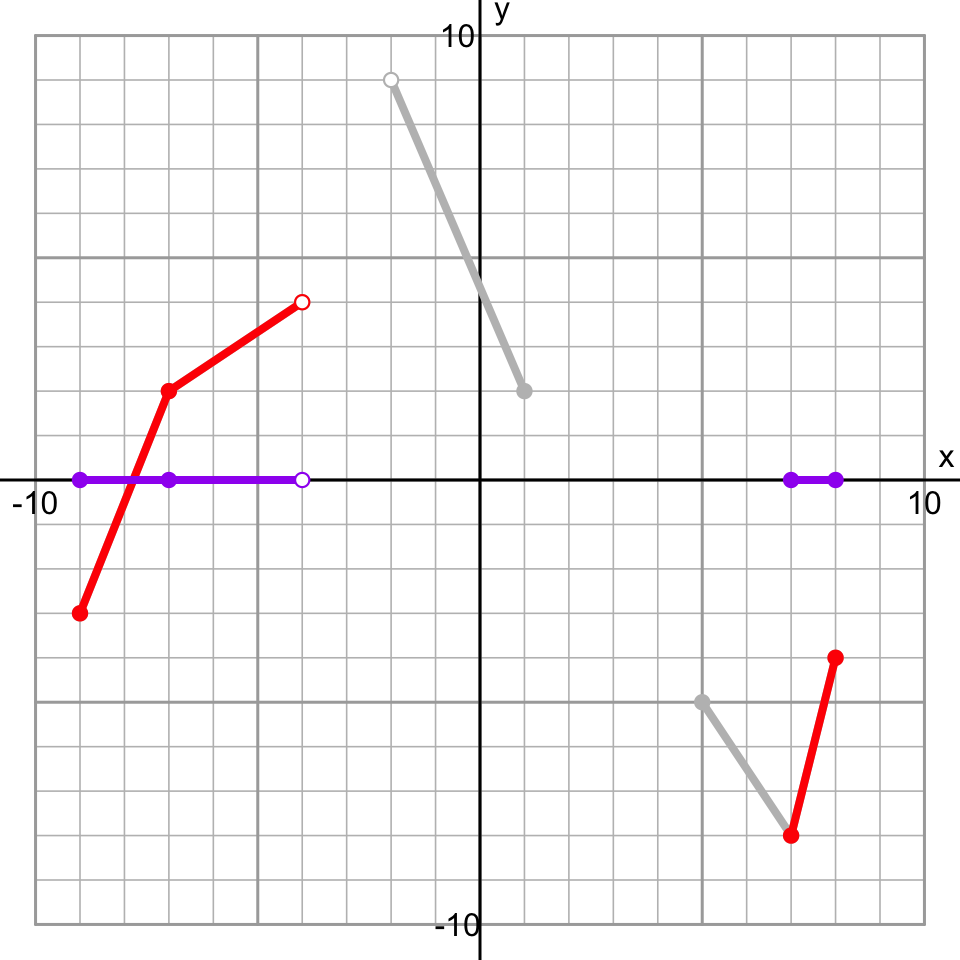

- $$[-9,-4)~\cup~[7,8]$$
- Although, if we want to get into a debate, I’d personally argue it is better to not include endpoints in intervals of increase/decrease. You can read a thorough treatment of this discussion here: https://www.themathdoctors.org/open-or-closed-intervals-it-depends/
- In other words, I’d also accept
  $$(-9,-4)~\cup~(7,8)$$

# Where is function DECREASING?

- Follow curve left to right (like when reading English).
- I imagine an ant hiking left to right along the mountain ridges.
- If curve is going down, it is decreasing.
- Using function notation, express where the function is increasing.
- Notice, on functions, we indicate “where” with the $x$ values.

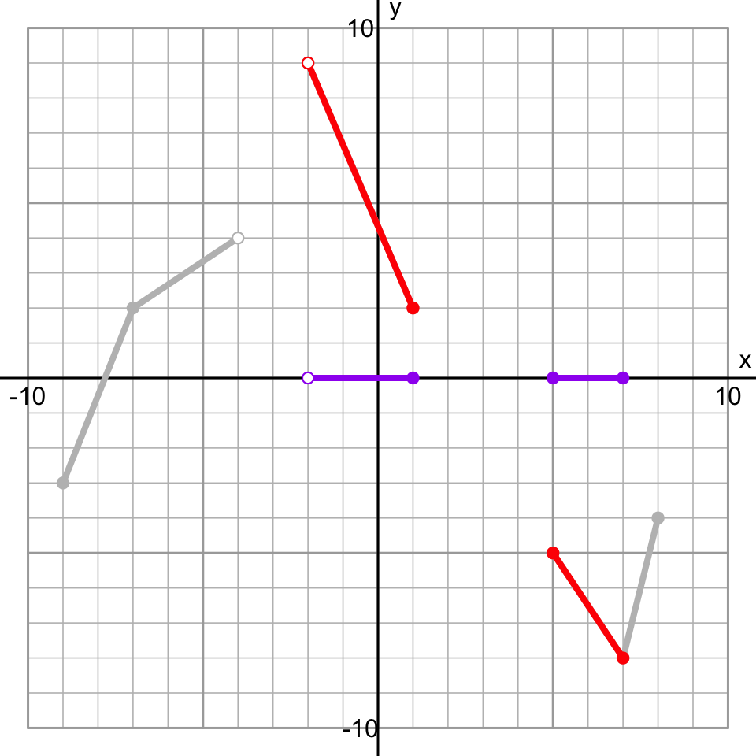

- $$(-2,1]~\cup~[5,7]$$
- Again, [we can argue](https://www.themathdoctors.org/open-or-closed-intervals-it-depends/) that the boundaries should not be included. So, I’d also accept
  $$(-2,1)~\cup~(5,7)$$

# Where is function POSITIVE?

- A function is positive where it is above the $x$ axis.

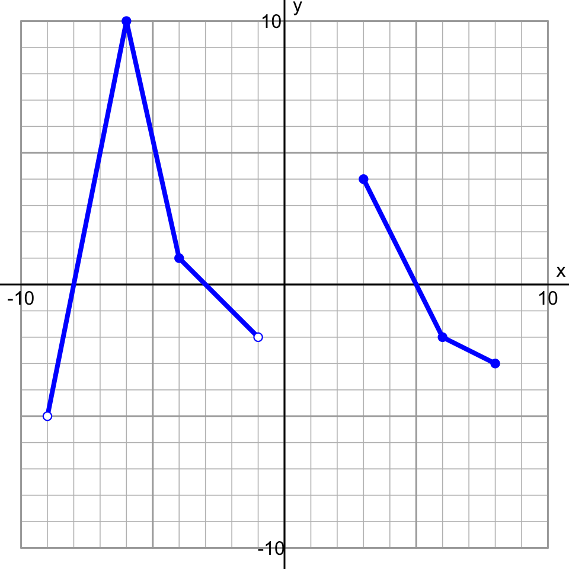

- Using function notation, express where the function is positive.
- (Remember, we are indicating $x$ values to denote “where” on a function.)

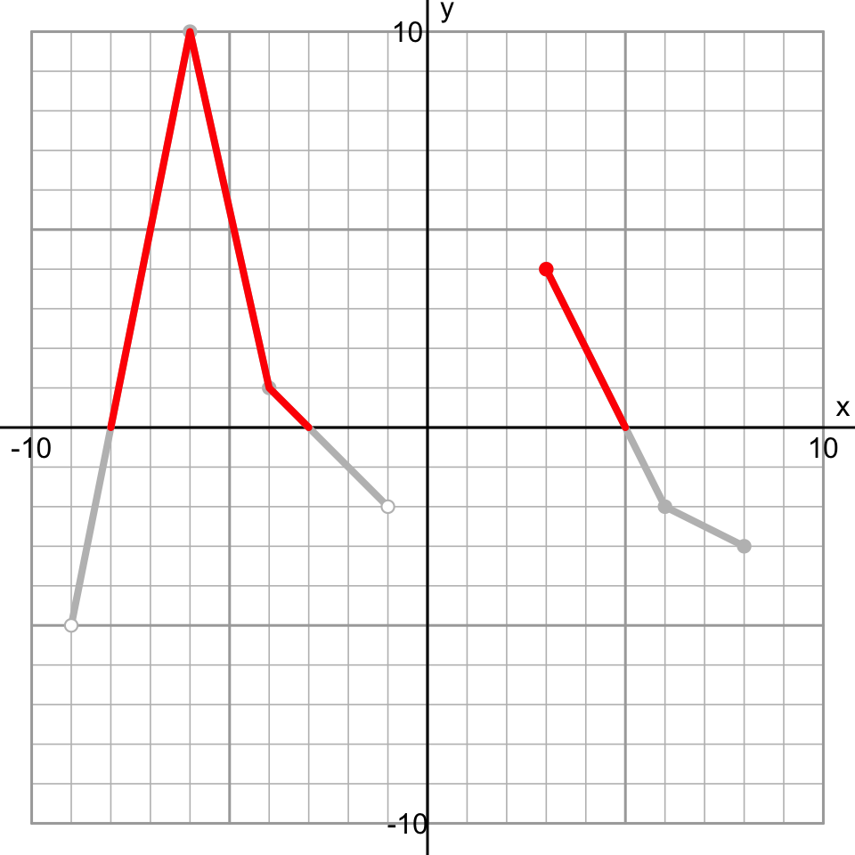

- The function is positive when $x$ is within the intervals indicated below:
  $$(-8,-3)~\cup~[3,5)$$
- Notice I am not including the $x$ intercepts, because 0 is not positive.

# Where is function NEGATIVE?

- A function is negative where it is below the $x$ axis.

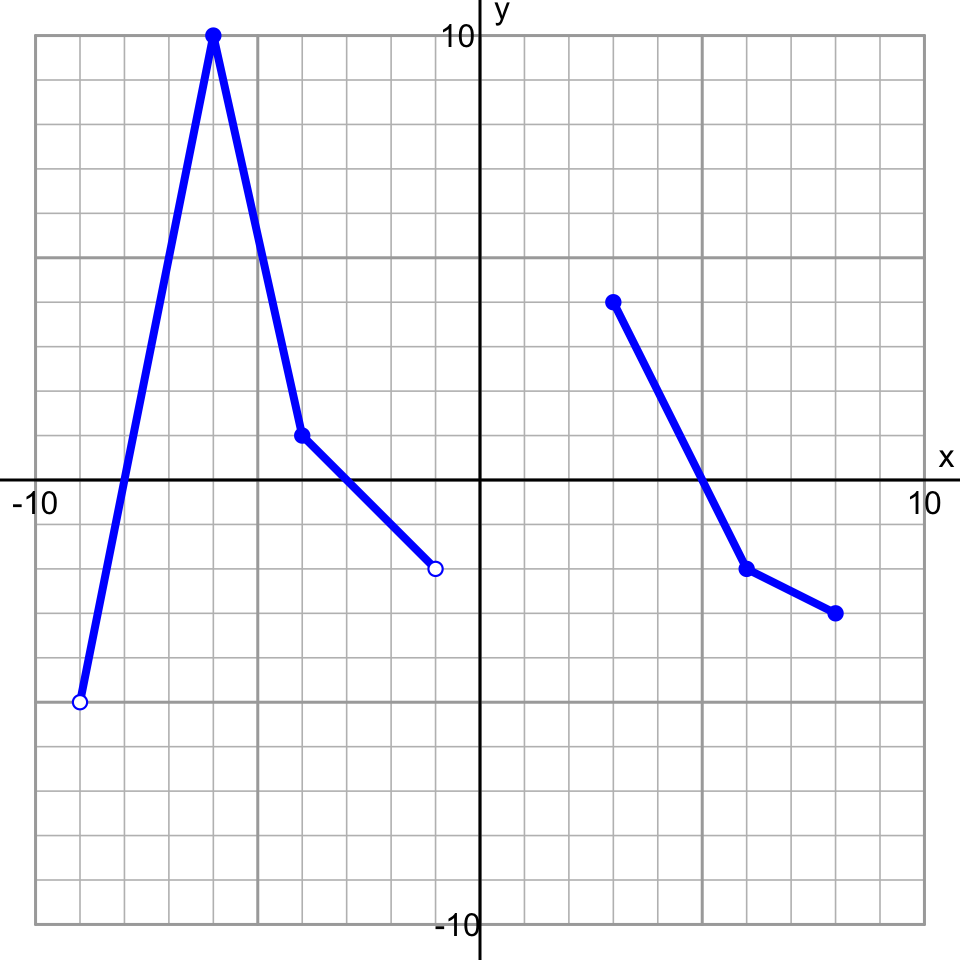

- Using function notation, express where the function is negative.

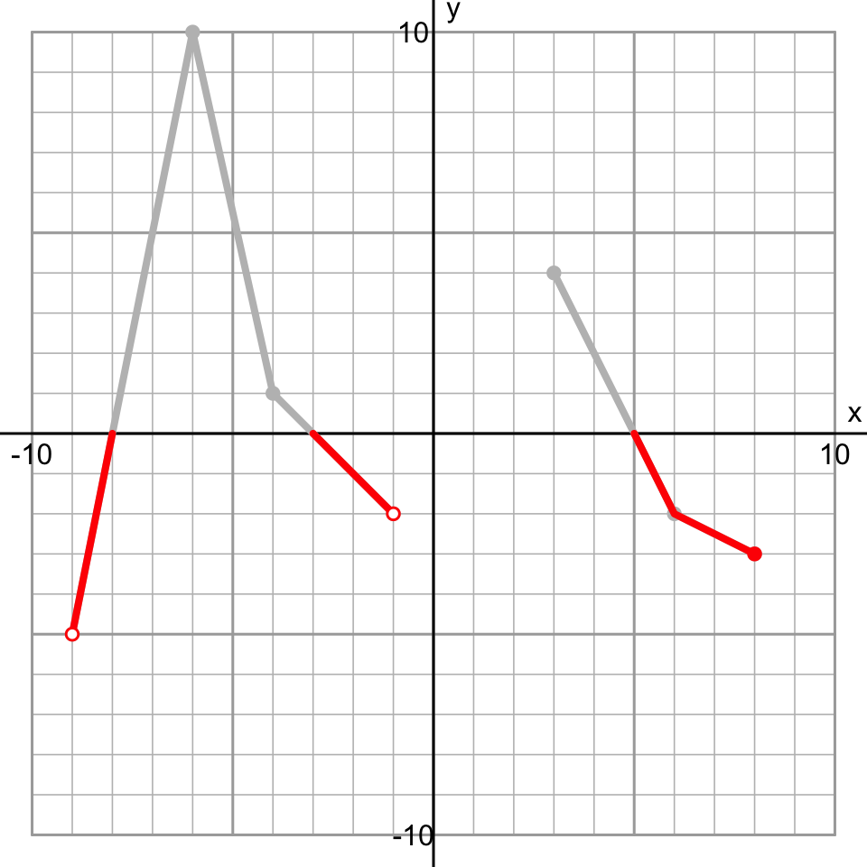

- The function is negative when $x$ is contained in the set of real numbers expressed below in interval notation:
  $$(-9,-8)~\cup~(-3,-1)~\cup~(5,8]$$
- Notice I am not including the $x$ intercepts, because 0 is not negative.